# Examen Final 2-2022 Grupo 01

Curso IE0217 Estructuras abstractas y algoritmos para ingeniería - UCR

Profesor Freddy Rojas

27/11/2022

# Examen Final Análisis de datos de la demanda eléctrica con Python

## Información preliminar de soporte para el examen.

El examen final del curso IE-0217 grupo 01 consiste en el una serie de análisis de información asociada a los datos de demanda eléctrica de varias plantas de generación eléctrica de Costa Rica.

Por parte del profesor será suminstrada una carpeta con nombre: *datos*, en la cual se ubican tres archivos de demanda correspondientes a los meses de abril, julio y setiembre del año 2022.

Los nombres son:

- EnergíaMensualHorariaPlantasSEN_4_2022.csv
- EnergíaMensualHorariaPlantasSEN_7_2022.csv
- EnergíaMensualHorariaPlantasSEN_9_2022.csv

En cada una de estos archivos aparecen las columnas con algunas de las plantas que producen generación eléctrica, así como las observaciones corresponden con los datos de demanda (MWh) producidos por hora durante el mes a que corresponde el archivo.

Estos datos son de dominio público y están disponibles mediante un acceso usando *servicios web*; estos consisten en usar el soporte del lenguaje *html* de las páginas **web** como mecanismo para solicitar información.

Los servicios WEB que se utilizaron para construir de forma iterativa los archivos de este examen, están detallados en la página del Centro Nacional de Control de Energía de Costa Rica (CENCE) en la dirección:

“https://apps.grupoice.com/CenceWeb/paginas/ServiciosWeb.html”

En la siguiente imagen se muestra el contenido de este sitio.

[figure not shown]

Vista de pagina de datos fuentes.

En esta página se pueden ver los diferentes servicios y los parámetros para accesarlos. Esta metodología es un tipo de Interfaz de Programación (API) que puede ser consultada en forma directa colocando la secuencia en la línea URL del navegador de internet, -que es poco práctico-, o mediante el soporte de lenguajes y aplicaciones que disponen de este mecanismo de acceso a los datos.

Cada uno de los grupos de datos que pueden ser accedidos se denominan “**endpoints**”. Para este examen se ha usado el servicio denominado “*EnergiaHorariaFuentePlanta*, permite obtener datos de una planta específica del sistema eléctrico nacional (SEN) y para los datos de energía de cada hora de un día específico.

Se ha realizado el acceso a esta interfaz y se han generado tres archivos que contienen los datos de la generación en los meses de Abril, Julio y Setiembre del año 2022. Estos archivos son los que serán utilizados para el planteamiento del examen.

### ENUNCIADO EXAMEN

Este examen es generado en forma aleatoria y es diferente al de los otros estudiantes, en todos los casos se solicitan *10* items (algunos con varios pasos) para concluir el examen.

Los datos solicitados a los estudios son diferentes para cada estudiante.

Las métodos solicitados a evaluar cambian según el estudio, así como los gráficos pedidos.

El examen se abre a las *3:00 p.m.* del *12 de diciembre del 2022* y el profesor mantendrá consultas hasta las 4:30 p.m. mediante la sesión abierta en la dirección de *Zoom* enviada por correo, para validar el código de examen. **No es la dirección usada en las clases**.

El tiempo de entrega del examen es a las *12:00* media noche del *12 de diciembre del 2022*.

Para la recepción del examen se usará el reservorio GIT, mismo que fue usado durante todo el curso para la entrega de las tareas. El examen es individual.

### Entorno de trabajo ( No se evalúa )

1. Deben construir una rama con el nombre *ExamenFinal2022* en su área de entrega de trabajos donde han entregado las tareas.
2. Copiar el archivo *EnergíaMensualHorariaPlantasSEN_9_2022.csv* del área de solución de tareas hacia su rama *ExamenFinal2022* en la carpeta: *ExamenFinalpy*.
3. Copiar el enunciado de este examen hacia su rama *ExamenFinal*. Esto es indispensable para conocer el número de examen al calificarlo. De no incluirse este archivo *NO SE CALIFICARÁ EL EXAMEN Y LA NOTA SERÁ 0.0*.
4. Realizar un *commit* indicando el mensaje “Enunciado” y realizar el *PUSH* y el *Merge Request* para que el profesor de por iniciado el examen y realice la acción de aceptación del comienzo del desarrollo del mismo.

Debe resolver el examen usando código en Python y pueden hacer el código de forma continuo. Es optativo el uso de funciones o clases, lo que queda a decisión de cada estudiante Se pueden usar segmentos de código visto en clase en las sesiones si lo consiera necesario.

### Parte 1 (40%) Conformación de los datos

Los pasos en la parte 1 son los siguientes:

1. Deben cargar las librerías necesarias de Python.

```python
#%%
import numpy as np
import pandas as pd
import prince
import os

import matplotlib.pyplot as plt
import seaborn as sns

from   sklearn.cluster import KMeans
from scipy.cluster.hierarchy import dendrogram, ward, single, complete,average,linkage, fcluster
from scipy.spatial.distance import pdist
```

2. Deben leer el archivo desde una carpeta de área de trabajo y asignarlo a la variable Pandas *Tabla*.

2.a) Debe asignar las “Fechas” como índice y pasarlas a formato de fecha (datetime).

2.b) Debe imprimir el contenido del archivo usando **print**.

La salida será similar a esta:

```
##                      Angostura    Arenal  ...  Ventanas  Ventanas-Garita
## Fechas                                    ...
## 2022-09-01 00:00:00  141.43675  30.56400  ...    1.9771         78.70962
## 2022-09-01 01:00:00  144.32775  30.44000  ...    4.9344         78.80025
## 2022-09-01 02:00:00  144.51775  30.42600  ...    4.9219         78.68850
## 2022-09-01 03:00:00  145.50100  30.41950  ...    4.9023         78.82038
## 2022-09-01 04:00:00  155.50350  30.44400  ...    4.8984         78.81987
## ...                        ...       ...  ...       ...              ...
## 2022-09-30 19:00:00  119.90800  28.79088  ...    7.6030         81.84650
## 2022-09-30 20:00:00  119.12800  29.56162  ...    0.8452         84.62275
## 2022-09-30 21:00:00  119.12000  32.52875  ...    0.0119         69.03525
## 2022-09-30 22:00:00  112.83600  30.65463  ...    0.5394         74.95050
## 2022-09-30 23:00:00  101.54400  29.68387  ...    5.7099         70.73025
##
## [720 rows x 41 columns]
```

2.c) La variable *Tabla* se usará como elemento base para resolver el examen y en cada una de las siguientes secciones será necesario copiarla a otro *dataframe* según sea el caso.

3. Deben copiar la *Tabla* a la variable *Tabla_caso1* y trabajar esta sección.
4. Usando el formato de *datetime* del index agregar una nueva columna con nombre “*SemanaIdx*” al dataframe *Tabla_caso1* que debe contener el número de la semana del año. Esto se hace con la función decorador *isocalendar().week* de la forma:

*Tabla_caso1[“SemanaIdx”]=Tabla_caso1.index.isocalendar().week*

Esta columna es la única forma de enumerar la semana del mes a partir de la semana del año. NO se deberá usar selección con las fechas directamente por rango, ya que esto no les da certeza automatizada y clara de la relación de la fecha con la semana del mes o del año.

Es importante tomar en cuenta que el método *isocalendar().week* toma la semana 1 del año a partir del primer *lunes* que corresponde al mes de enero.

En el caso de los archivos analizados para el año 2022; la semana 1 inicia el 03 de Enero ya que el primero de Enero es sábado y por lo tanto las fechas 01 y 02 pertenecen a la última semana (la 52) del año 2021.

Además deben obtener el día de la semana con el método *day*

*Tabla_caso1[“DiaIdx”]=Tabla_caso1.index.isocalendar().day*

La salida debe ser similar a esta:

```
##                      Angostura    Arenal  ...  SemanaIdx  DiaIdx
## Fechas                                    ...
## 2022-09-01 00:00:00  141.43675  30.56400  ...         35       4
## 2022-09-01 01:00:00  144.32775  30.44000  ...         35       4
## 2022-09-01 02:00:00  144.51775  30.42600  ...         35       4
## 2022-09-01 03:00:00  145.50100  30.41950  ...         35       4
## 2022-09-01 04:00:00  155.50350  30.44400  ...         35       4
## ...                        ...       ...  ...        ...     ...
## 2022-09-30 19:00:00  119.90800  28.79088  ...         39       5
## 2022-09-30 20:00:00  119.12800  29.56162  ...         39       5
## 2022-09-30 21:00:00  119.12000  32.52875  ...         39       5
## 2022-09-30 22:00:00  112.83600  30.65463  ...         39       5
## 2022-09-30 23:00:00  101.54400  29.68387  ...         39       5
##
## [720 rows x 43 columns]
```

4.a) Si se aplica el método *unique* a la columna *SemanaIdx* de *Tabla_caso1*, se puede obtener un arreglo de enteros con los valores de las semanas del año.

```python
indice_semanas=Tabla_caso1.SemanaIdx.unique()
```

4.b) Para seleccionar las semanas del mes, esa corresponde a la POSICION dentro de la variable *indice_semanas*.

```
## La semana número 1 (A) del mes de su examen corresponde a la semana número 35 del año.
```

```
## La semana número 3 (B) del mes de su examen corresponde a la semana número 37 del año.
```

*Tip:*

Para filtrar las semanas usando la variable *SemanaIdx* hay que comparar esta columna con las semanas pedidas. Para ello hay varias formas; una de estas se puede realizar usando la operación *apply* en la *Tabla_caso1* y el comodín *lambda* sobre la variable *SemanaIdx* sobre las columnas ( *axis=1* ), según se explicó en clases.

Otra forma es generar una variable “booleana” a partir de comparar *SemanaIdx* con las semanas del mes solicitadas y el resultado usarlo para dejar las observaciones (fechas) que corresponden con esas semanas de interés.

Aplicar el procedimiento de selección de las semanas solicitadas en el enunciado

Con esto se tiene una tabla con todas las variables correspondientes a las plantas de generación y las observaciones para las semanas pedidas.

El resultado es similar a este:

```
##                      Angostura    Arenal  ...  SemanaIdx  DiaIdx
## Fechas                                    ...
## 2022-09-01 00:00:00  141.43675  30.56400  ...         35       4
## 2022-09-01 01:00:00  144.32775  30.44000  ...         35       4
## 2022-09-01 02:00:00  144.51775  30.42600  ...         35       4
## 2022-09-01 03:00:00  145.50100  30.41950  ...         35       4
## 2022-09-01 04:00:00  155.50350  30.44400  ...         35       4
## ...                        ...       ...  ...        ...     ...
## 2022-09-18 19:00:00  166.11900  30.01775  ...         37       7
## 2022-09-18 20:00:00  156.84000  29.87700  ...         37       7
## 2022-09-18 21:00:00  152.07800  29.90200  ...         37       7
## 2022-09-18 22:00:00  155.96700  30.17450  ...         37       7
## 2022-09-18 23:00:00  154.10600  30.44850  ...         37       7
##
## [264 rows x 43 columns]
```

### Parámetros a utilizar:

- Archivo a utilizar: *EnergíaMensualHorariaPlantasSEN_9_2022.csv*

Del mes al cual corresponde el archivo, se van a separar las semanas número *1* y número *3*.

- Plantas de generación a utilizar: *TODOS*.
- Fechas a procesar en parte 2: Se usarán todos los días de la semana *1*
- Fechas a procesar en parte 3: Se utilizarán solo los días laborales de las semana *3*

En python:

*filename_eval=“EnergíaMensualHorariaPlantasSEN_9_2022.csv”*

*SemanaA=1*

*SemanaB=3*

### Parte 2 (30%) Análsis de datos con Plantas de generación como variables.

1. Deben copiar la *Tabla_caso1* a la variable *Tabla_caso2* y trabajarla esta sección.

1.a) Con esta tabla (*Tabla_caso2*) se deben separar las dos semanas en estudio en dos tablas derivadas.

Para ello se puede agrupar por la variable *SemanaIdx* y se seleccionan con el método *get_group* cada semana ubicándolas en las variables *Tabla_caso2_semanaA* y *Tabla_caso2_semanaB* respectivamente. Refiéranse al material de la clase 31 en el GIT del curso.

Luego se elimina la columna *SemanaIdx* de las tablas *Tabla_caso2_semanaA* y *Tabla_caso2_semanaB*

La salida de las tablas es similar a esta:

```
##                      Angostura    Arenal  ...  Ventanas-Garita  DiaIdx
## Fechas                                    ...
## 2022-09-01 00:00:00  141.43675  30.56400  ...         78.70962       4
## 2022-09-01 01:00:00  144.32775  30.44000  ...         78.80025       4
## 2022-09-01 02:00:00  144.51775  30.42600  ...         78.68850       4
## 2022-09-01 03:00:00  145.50100  30.41950  ...         78.82038       4
## 2022-09-01 04:00:00  155.50350  30.44400  ...         78.81987       4
## ...                        ...       ...  ...              ...     ...
## 2022-09-04 19:00:00  108.14850  40.17806  ...         79.72533       7
## 2022-09-04 20:00:00  113.33950  38.67912  ...         79.46205       7
## 2022-09-04 21:00:00  104.76350  32.34482  ...         79.78465       7
## 2022-09-04 22:00:00  110.76900  30.30187  ...         79.64013       7
## 2022-09-04 23:00:00  108.64200  29.69794  ...         79.49634       7
##
## [96 rows x 42 columns]
```

```
##                      Angostura    Arenal  ...  Ventanas-Garita  DiaIdx
## Fechas                                    ...
## 2022-09-12 00:00:00  109.90543  33.08100  ...         78.46150       1
## 2022-09-12 01:00:00  108.53363  30.51500  ...         78.39250       1
## 2022-09-12 02:00:00  108.38012  30.40500  ...         78.12000       1
## 2022-09-12 03:00:00  100.06657  30.68700  ...         78.08512       1
## 2022-09-12 04:00:00  108.76137  30.97100  ...         78.08100       1
## ...                        ...       ...  ...              ...     ...
## 2022-09-18 19:00:00  166.11900  30.01775  ...         78.99400       7
## 2022-09-18 20:00:00  156.84000  29.87700  ...         78.96100       7
## 2022-09-18 21:00:00  152.07800  29.90200  ...         78.87075       7
## 2022-09-18 22:00:00  155.96700  30.17450  ...         78.78575       7
## 2022-09-18 23:00:00  154.10600  30.44850  ...         78.99425       7
##
## [168 rows x 42 columns]
```

En la tabla *Tabla_caso2_semanaB* se deben seleccionar las observaciones correspondientes a los días laborales de la semana (lunes, martes, miércoles, jueves y viernes), para ello se usa el filtrado con *lambda* y se seleccionan los valores de la columna *DiaIdx* en una lista [1,2,3,4,5]

Una vez filtrados los días laborales únicamente se procede a eliminar la columna *DiaIdx*

En la tabla *Tabla_caso2_semanaA* se elimina la columa *DiaIdx* para procesarla luego. Esto implica que posteriormente se analizarán todos los días de la semana A

2 ) Deben realizar el análisis de *H Clustering* usando el método ‘*Ward*’ a partir de los datos contenidos *Tabla_caso2_semanaA* para 4 (cuatro) grupos.

2.a) presentar los cluster resultantes con el a partir del uso del paquete *fcluster*.

2.b) Generar los centros agregando la columna “*cluster*” a una copia de la *Tabla_caso2*, haciendo agrupación por “cluster” y tomando los valores medios mediante agregación.

2.b) Realice el gráfico de barras con los centros según se vio en clases para cada uno de los grupos.

3. Realice sus comentarios sobre lo observado.

¿Aparecen datos negativos?, ¿A que fuente corresponden de existir? ¿Qué significan si la generación de una unidad generadora siempre es positiva?

### Parte 3 (30%) Análsis de datos detallado con Plantas de generación como observaciones.

4.a) presentar los cluster resultantes con el decorador *labels_* y los centros resultantes.

4.b) Realice un gráfico lineal con los trazos de los 4 centros.

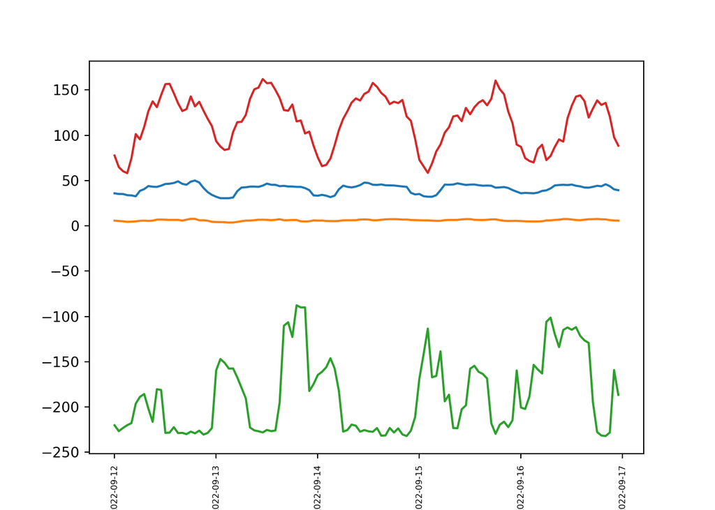

4.c) Muestre la lista de las plantas que corresponden con cada ‘cluster’.

Que conclusiones puede dar de los gráficos y las plantas de generación que conforman estos grupos.

5. Dendograma

Realice un dendograma de los datos de *Tabla_caso3* tipo *ward*

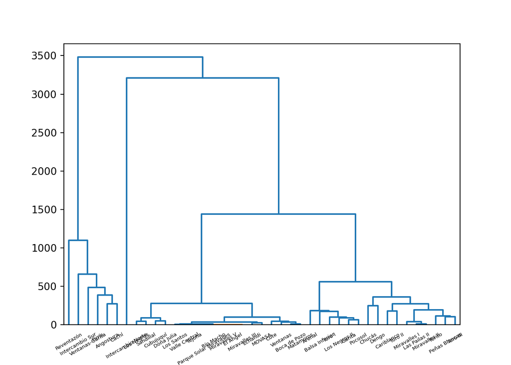

6. Análisis ACP.

6.a) Realice un análisis por componentes principales sobre el dataframe *Tabla_caso3* para 3 grupos y muestre la transformación (datos en 2D) resultante.

6.c) Comente los resultados al comparar el gráfico de ACP con el dendograma.